# Country differences in ERC success rates

### Rui Mata, [University of Basel](https://www.cds.unibas.ch)

## Goal

I was interested in assessing country differences in ERC success rates and potential relation to investment in research and development, with a particular focus on Portugal, Germany, and Switzerland.

## Data

First, I manually downloaded publicly available statiscts from [erc.europa.eu](https://erc.europa.eu/projects-figures/statistics) that included the number of evaluated and granted proposals for ERC Starting, Consolidator, and Advanced Grants.

Second, I used the eurostat R package to access [eurostat](https://ec.europa.eu/eurostat/statistics-explained/index.php?title=R%26D_expenditure&oldid=551418#Gross_domestic_expenditure_on_R.26D) statistics concerning the Gross domestic Expenditure on Research and Development (GERD) of European countries.

## Results

#### Overall Success Rate

I calculated the overall success rate across all available years for Starting, Consolidator, and Advanced Grants as the total number of funded grants divided by total submissions.

The overall rate was 11.6% but this global rate hides considerable country differences. The table below shows success rates, including those for PT (8%), DE (16%), and CH (23%).

|  | Country | Success |
| --- | --- | --- |
| 1 | Albania | 0 |
| 2 | Armenia | 0 |
| 3 | Austria | 16 |
| 4 | Bosnia &amp; Herzegovina | 0 |
| 5 | Belgium | 14 |
| 6 | Bulgaria | 0 |
| 7 | Switzerland | 23 |
| 8 | Cyprus | 0 |
| 9 | Czechia | 5 |
| 10 | Germany | 16 |

[output cut: 32 more lines]

#### Success Rate by GERD

To explore the link between country differences in ERC success rates and each country’s investment in research and development, I used a scatterplot linking success rates as calculated above and the GERD (Gross domestic Expenditure on Research and Development) data available from Eurostat.

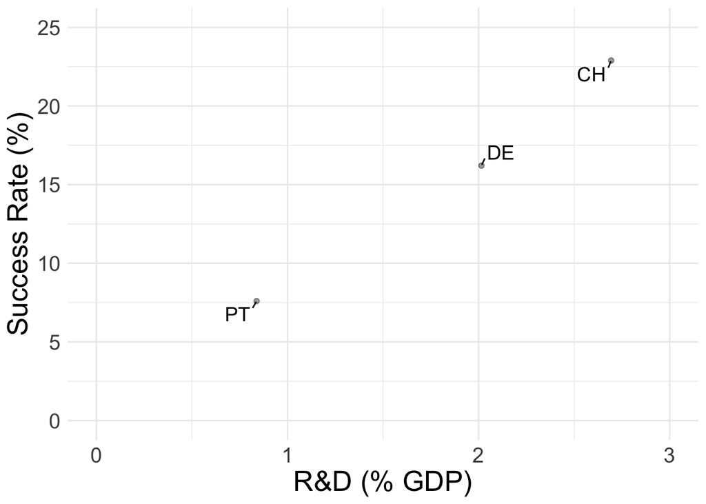

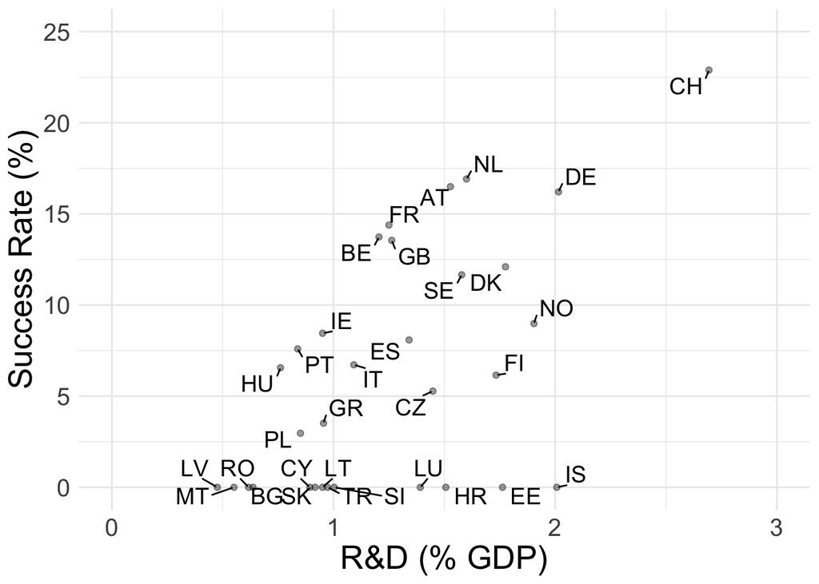